# Extracting Stock Data Using a Python Library

Now we can access functions and variables to extract the type of data we need. You can view them and what they represent here https://aroussi.com/post/python-yahoo-finance.

```python
!wget https://cf-courses-data.s3.us.cloud-object-storage.appdomain.cloud/IBMDeveloperSkillsNetwork-PY0220EN-SkillsNetwork/data/apple.json
```

```
--2024-12-26 19:48:57--  https://cf-courses-data.s3.us.cloud-object-storage.appdomain.cloud/IBMDeveloperSkillsNetwork-PY0220EN-SkillsNetwork/data/apple.json
Resolving cf-courses-data.s3.us.cloud-object-storage.appdomain.cloud (cf-courses-data.s3.us.cloud-object-storage.appdomain.cloud)... 169.63.118.104, 169.63.118.104
Connecting to cf-courses-data.s3.us.cloud-object-storage.appdomain.cloud (cf-courses-data.s3.us.cloud-object-storage.appdomain.cloud)|169.63.118.104|:443... connected.
HTTP request sent, awaiting response... 200 OK
Length: 5699 (5.6K) [application/json]
Saving to: ‘apple.json’

apple.json          100%[===================>]   5.57K  --.-KB/s    in 0s

2024-12-26 19:48:57 (1006 MB/s) - ‘apple.json’ saved [5699/5699]
```

The format that the data is returned in is a Pandas DataFrame. With the `Date` as the index the share `Open`, `High`, `Low`, `Close`, `Volume`, and `Stock Splits` are given for each day.

```python
apple_share_price_data.head()
```

| Date | Open | High | Low | Close | Volume | Dividends | Stock Splits |
| --- | --- | --- | --- | --- | --- | --- | --- |
| 1980-12-12 00:00:00-05:00 | 0.098834 | 0.099264 | 0.098834 | 0.098834 | 469033600 | 0.0 | 0.0 |
| 1980-12-15 00:00:00-05:00 | 0.094108 | 0.094108 | 0.093678 | 0.093678 | 175884800 | 0.0 | 0.0 |
| 1980-12-16 00:00:00-05:00 | 0.087232 | 0.087232 | 0.086802 | 0.086802 | 105728000 | 0.0 | 0.0 |
| 1980-12-17 00:00:00-05:00 | 0.088951 | 0.089381 | 0.088951 | 0.088951 | 86441600 | 0.0 | 0.0 |
| 1980-12-18 00:00:00-05:00 | 0.091530 | 0.091959 | 0.091530 | 0.091530 | 73449600 | 0.0 | 0.0 |

We can reset the index of the DataFrame with the `reset_index` function. We also set the `inplace` paramter to `True` so the change takes place to the DataFrame itself.

```python
apple_share_price_data.reset_index(inplace=True)
```

We can plot the `Open` price against the `Date`:

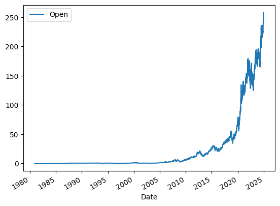

```python
apple_share_price_data.plot(x="Date", y="Open")
```

### Extracting Dividends

Dividends are the distribution of a companys profits to shareholders. In this case they are defined as an amount of money returned per share an investor owns. Using the variable `dividends` we can get a dataframe of the data. The period of the data is given by the period defined in the 'history` function.

```python
apple.dividends
```

```
Date
1987-05-11 00:00:00-04:00    0.000536
1987-08-10 00:00:00-04:00    0.000536
1987-11-17 00:00:00-05:00    0.000714
1988-02-12 00:00:00-05:00    0.000714
1988-05-16 00:00:00-04:00    0.000714
                               ...
2023-11-10 00:00:00-05:00    0.240000
2024-02-09 00:00:00-05:00    0.240000
2024-05-10 00:00:00-04:00    0.250000
2024-08-12 00:00:00-04:00    0.250000
2024-11-08 00:00:00-05:00    0.250000
Name: Dividends, Length: 85, dtype: float64
```

We can plot the dividends overtime:

```python
apple.dividends.plot()
```

[output not shown]

## Exercise

Now using the `Ticker` module create an object for AMD (Advanced Micro Devices) with the ticker symbol is `AMD` called; name the object `amd`.

```python
!wget https://cf-courses-data.s3.us.cloud-object-storage.appdomain.cloud/IBMDeveloperSkillsNetwork-PY0220EN-SkillsNetwork/data/amd.json
```

```python
import json
with open('amd.json') as json_file:
    amd_info = json.load(json_file)
    # Print the type of data variable
    #print("Type:", type(apple_info))
amd_info
```

**Question 1** Use the key `'country'` to find the country the stock belongs to, remember it as it will be a quiz question.

**Question 2** Use the key `'sector'` to find the sector the stock belongs to, remember it as it will be a quiz question.

**Question 3** Obtain stock data for AMD using the `history` function, set the `period` to max. Find the `Volume` traded on the first day (first row).

## About the Authors:

[Joseph Santarcangelo](https://www.linkedin.com/in/joseph-s-50398b136/) has a PhD in Electrical Engineering, his research focused on using machine learning, signal processing, and computer vision to determine how videos impact human cognition. Joseph has been working for IBM since he completed his PhD.

Azim Hirjani

```python
!pip install yfinance beautifulsoup4 pandas matplotlib
```

[output not shown]

```python
import yfinance as yf

# Download Tesla stock data
tesla_data = yf.Ticker("TSLA").history(period="max")

# Reset the index
tesla_data.reset_index(inplace=True)

# Display the first 5 rows
tesla_data.head()
```

|  | Date | Open | High | Low | Close | Volume | Dividends | Stock Splits |
| --- | --- | --- | --- | --- | --- | --- | --- | --- |
| 0 | 2010-06-29 00:00:00-04:00 | 1.266667 | 1.666667 | 1.169333 | 1.592667 | 281494500 | 0.0 | 0.0 |
| 1 | 2010-06-30 00:00:00-04:00 | 1.719333 | 2.028000 | 1.553333 | 1.588667 | 257806500 | 0.0 | 0.0 |
| 2 | 2010-07-01 00:00:00-04:00 | 1.666667 | 1.728000 | 1.351333 | 1.464000 | 123282000 | 0.0 | 0.0 |
| 3 | 2010-07-02 00:00:00-04:00 | 1.533333 | 1.540000 | 1.247333 | 1.280000 | 77097000 | 0.0 | 0.0 |
| 4 | 2010-07-06 00:00:00-04:00 | 1.333333 | 1.333333 | 1.055333 | 1.074000 | 103003500 | 0.0 | 0.0 |

```python
import requests
from bs4 import BeautifulSoup

# Fetch the webpage content
url = "https://www.macrotrends.net/stocks/charts/TSLA/tesla/revenue"
html = requests.get(url).text

# Parse the HTML content
soup = BeautifulSoup(html, "html.parser")

# Extract and print all tables
tables = soup.find_all("table")

# Debug: Print the content of all tables
for idx, table in enumerate(tables):
    print(f"Table {idx}:\n{table}\n")
```

```python
import yfinance as yf
import pandas as pd
import requests
from bs4 import BeautifulSoup

tesla = yf.Ticker("TSLA")

tesla_revenue = pd.DataFrame(columns=["Date", "Revenue"])

url = "https://www.macrotrends.net/stocks/charts/TSLA/tesla/revenue"
html_data = requests.get(url).text

soup = BeautifulSoup(html_data, "html5lib")

for table in soup.find_all('table'):

    if ("Tesla Quarterly Revenue" in table.find('th').text):
        table_rows = table.find_all('tr')

        del table_rows[0]

        for row in table_rows:
            col = row.find_all('td')
            date = col[0].text
            revenue = col[1].text.replace("$", "").replace(",", "")

            tesla_revenue = tesla_revenue.append({"Date": date, "Revenue": revenue}, ignore_index=True)

tesla_revenue["Revenue"] = tesla_revenue["Revenue"].str.replace(",", "").str.replace("$", "")

tesla_revenue.dropna(inplace=True)

tesla_revenue = tesla_revenue[tesla_revenue['Revenue'] != ""]

print(tesla_revenue.tail())
```

```
Empty DataFrame
Columns: [Date, Revenue]
Index: []
```

```python
import pandas as pd
import requests
from bs4 import BeautifulSoup

def get_tesla_revenue():
    tesla_revenue = pd.DataFrame(columns=["Date", "Revenue"])
    url = "https://www.macrotrends.net/stocks/charts/TSLA/tesla/revenue"
    try:
        html_data = requests.get(url, timeout=10).text  # Add timeout
    except requests.exceptions.RequestException as e:
        print(f"Error fetching URL: {e}")
        return pd.DataFrame()  # Return empty DataFrame on error

    soup = BeautifulSoup(html_data, "html5lib")

    for table in soup.find_all('table'):
        if "Tesla Quarterly Revenue" in table.find('th', class_='table-header').text: #improved selection
            table_rows = table.find_all('tr')
            del table_rows[0] #remove header row

            for row in table_rows:
                col = row.find_all('td')
                if len(col) >= 2: #check if the row has enough columns
                    date = col[0].text.strip()
                    revenue = col[1].text.strip().replace("$", "").replace(",", "")
                    try:
                        revenue = int(revenue) #convert to int if possible
                    except ValueError:
                        pass # if not a number keep as string
                    tesla_revenue = pd.concat([tesla_revenue, pd.DataFrame([{'Date': date, 'Revenue': revenue}])], ignore_index=True)
            break #exit after finding the correct table

    tesla_revenue.dropna(inplace=True)
    tesla_revenue = tesla_revenue[tesla_revenue['Revenue'] != ""]
    return tesla_revenue

if __name__ == "__main__":
  tesla_revenue = get_tesla_revenue()
  if not tesla_revenue.empty: #check if data frame is empty before printing
    print(tesla_revenue.tail().to_string())
  else:
    print("Could not retrieve Tesla Revenue data.")
```

```
Could not retrieve Tesla Revenue data.
```

```python
# Download GameStop stock data
gme_data = yf.Ticker("GME").history(period="max")

# Reset the index
gme_data.reset_index(inplace=True)

# Display the first 5 rows
gme_data.head()
```

|  | Date | Open | High | Low | Close | Volume | Dividends | Stock Splits |
| --- | --- | --- | --- | --- | --- | --- | --- | --- |
| 0 | 2002-02-13 00:00:00-05:00 | 1.620129 | 1.693350 | 1.603296 | 1.691667 | 76216000 | 0.0 | 0.0 |
| 1 | 2002-02-14 00:00:00-05:00 | 1.712707 | 1.716073 | 1.670626 | 1.683250 | 11021600 | 0.0 | 0.0 |
| 2 | 2002-02-15 00:00:00-05:00 | 1.683251 | 1.687459 | 1.658002 | 1.674834 | 8389600 | 0.0 | 0.0 |
| 3 | 2002-02-19 00:00:00-05:00 | 1.666418 | 1.666418 | 1.578048 | 1.607504 | 7410400 | 0.0 | 0.0 |
| 4 | 2002-02-20 00:00:00-05:00 | 1.615921 | 1.662210 | 1.603296 | 1.662210 | 6892800 | 0.0 | 0.0 |

[figure not shown]

```python
import matplotlib.pyplot as plt

def make_graph(stock_data, revenue_data, stock_title):
    fig, ax1 = plt.subplots(figsize=(14, 7))

    ax1.set_xlabel('Date')
    ax1.set_ylabel('Stock Price', color='tab:blue')
    ax1.plot(stock_data['Date'], stock_data['Close'], color='tab:blue', label="Stock Price")
    ax1.tick_params(axis='y', labelcolor='tab:blue')

    ax2 = ax1.twinx()
    ax2.set_ylabel('Revenue', color='tab:red')
    ax2.plot(revenue_data['Date'], revenue_data['Revenue'], color='tab:red', label="Revenue")
    ax2.tick_params(axis='y', labelcolor='tab:red')

    plt.title(stock_title)
    plt.show()

# Call the function for Tesla
make_graph(tesla_data, tesla_revenue, "Tesla Stock Price vs Revenue")
```

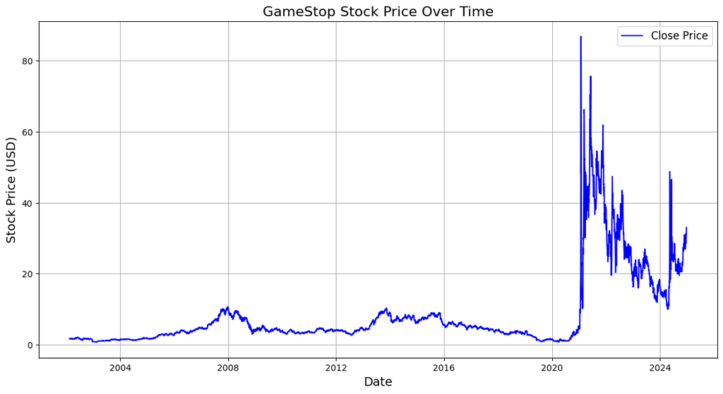

```python
import yfinance as yf
import matplotlib.pyplot as plt

# Step 1: Extract GameStop Stock Data
gme_data = yf.Ticker("GME")
gme_df = gme_data.history(period="max")
gme_df.reset_index(inplace=True)

# Step 2: Define the make_graph function
def make_graph(data, title):
    plt.figure(figsize=(14, 7))
    plt.plot(data["Date"], data["Close"], label="Close Price", color="blue")
    plt.title(title, fontsize=16)
    plt.xlabel("Date", fontsize=14)
    plt.ylabel("Stock Price (USD)", fontsize=14)
    plt.legend(fontsize=12)
    plt.grid(True)
    plt.show()

make_graph(gme_df, "GameStop Stock Price Over Time")
```